# Developing Data Products - Assignment Week 4 Pitch

7/26/2021

## Objective

This peer assessed assignment has two parts. First, you will create a Shiny application and deploy it on Rstudio’s servers. Second, you will use Slidify or Rstudio Presenter to prepare a reproducible pitch presentation about your application.

*Your Shiny Application*

1. Write a shiny application with associated supporting documentation. The documentation should be thought of as whatever a user will need to get started using your application.
2. Deploy the application on Rstudio’s shiny server
3. Share the application link by pasting it into the provided text box
4. Share your server.R and ui.R code on github

## Objective - Grading Criteria

The application must include the following:

1. Some form of input (widget: textbox, radio button, checkbox, …)
2. Some operation on the ui input in sever.R
3. Some reactive output displayed as a result of server calculations
4. You must also include enough documentation so that a novice user could use your application.
5. The documentation should be at the Shiny website itself. Do not post to an external link.

## Data

For creating this Shiny application, we use the mtcars dataset. The data can be found [here](https://class.coursera.org/regmods-008):

https://class.coursera.org/regmods-008 Source:Henderson and Velleman (1981), Building multiple regression models interactively. Biometrics, 37, 391-411.

The data was extracted from the 1974 Motor Trend US magazine,and comprises fuel consumption and 10 aspects of automobile design and performance for 32 automobiles (1973-74 models).

## Data Details

A data frame with 32 observations on 11 variables.

[output not shown]

## Data Sample

```r
data(mtcars)
head(mtcars, n=3)
```

```
##                mpg cyl disp  hp drat    wt  qsec vs am gear carb
## Mazda RX4     21.0   6  160 110 3.90 2.620 16.46  0  1    4    4
## Mazda RX4 Wag 21.0   6  160 110 3.90 2.875 17.02  0  1    4    4
## Datsun 710    22.8   4  108  93 3.85 2.320 18.61  1  1    4    1
```

```r
#str(mtcars)
#summary(mtcars)
```

## Application

The application lets you examine the relationshop of various variables with the fuel consumption (mpg). The application allows users to select variables to examine their univariate linear regression results in relation to mpg. The box plot is hsown in a different tab, where users can choose to include or omit to show outliers.

## Screenshot - Box Plot

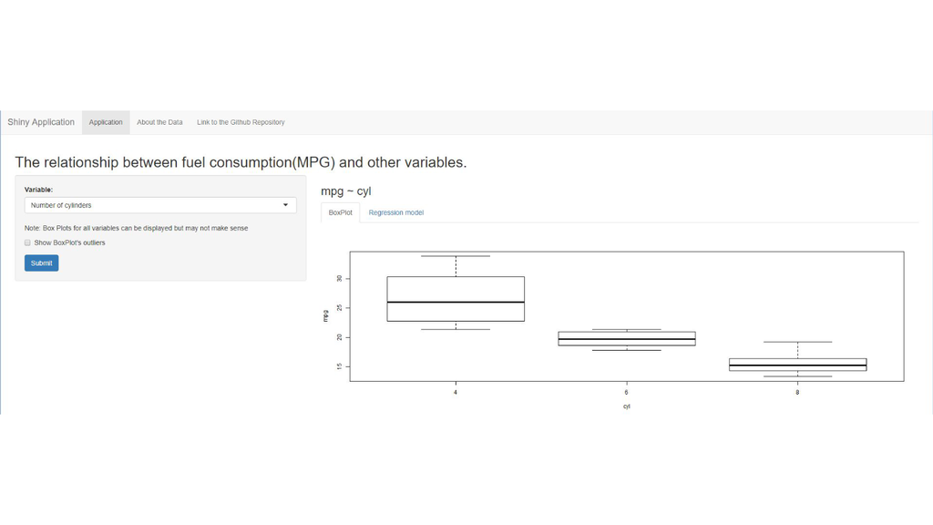

## Screenshot - Regression Model

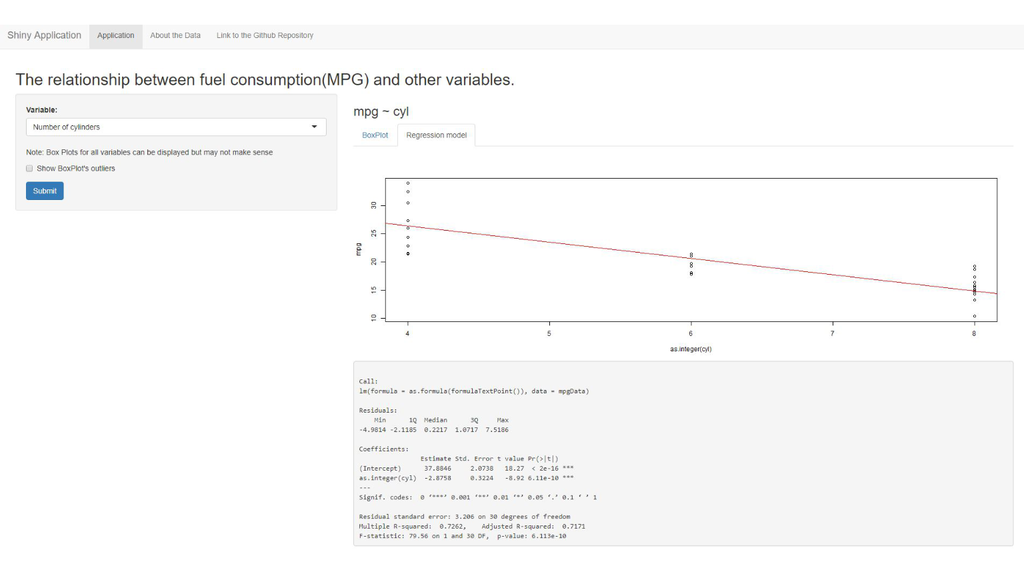

## Code

The code for the application can be found in the GitHub repository located [here](https://github.com/sregmi84/Developing-Data-Products---Data-Science): [https://github.com/sregmi84/Developing-Data-Products—Data-Science](https://github.com/sregmi84/Developing-Data-Products---Data-Science)